# PEC3_ANOVA Y PCA

Nathalia Fernandez Rodrigues

26/1/2021

Se carga el fichero de datos **“car_net.csv”** del directorio de trabajo y se guardan los datos en un objeto llamado **“car”**

```r
setwd("C:/PEC3")
car<- read.csv("car_net.csv", header=TRUE, sep=",", dec=".", fileEncoding = "UTF-8")
getwd()
```

```
## [1] "C:/PEC3"
```

# 1 **Carga y preparación del juego de datos**

```r
summary(car)
```

```
##       Fabricante      Modelo        Ventas        Valor_usado
##  Dodge     : 11   Neon   :  2   Min.   :   110   Min.   : 5160
##  Ford      : 11   3-Sep  :  1   1st Qu.: 14114   1st Qu.:11260
##  Chevrolet :  9   3000GT :  1   Median : 29450   Median :14180
##  Mercedes-B:  9   300M   :  1   Mean   : 52998   Mean   :18073
##  Toyota    :  9   323i   :  1   3rd Qu.: 67956   3rd Qu.:19875
##  Chrysler  :  7   328i   :  1   Max.   :540561   Max.   :67550
##  (Other)   :101   (Other):150                    NA's   :36
##       Tipo_vehiculo     Precio          Motor         Caballos
##  No pasajeros: 41   Min.   : 9235   Min.   :1000   Min.   : 55.0
##  Pasajeros   :116   1st Qu.:18018   1st Qu.:2300   1st Qu.:149.5
##                     Median :22799   Median :3000   Median :177.5
##                     Mean   :27391   Mean   :3061   Mean   :185.9
##                     3rd Qu.:31948   3rd Qu.:3575   3rd Qu.:215.0
##                     Max.   :85500   Max.   :8000   Max.   :450.0
##                     NA's   :2       NA's   :1      NA's   :1
##  Ejes_distancia     Ancho        Longitud       PesoBruto
##  Min.   :2.35     1.76 :  8   Min.   :3.790   Min.   :1719
##  1st Qu.:2.62     1.69 :  7   1st Qu.:4.510   1st Qu.:2695
##  Median :2.72     1.79 :  7   Median :4.775   Median :3032
##  Mean   :2.73     1.82 :  7   Mean   :4.759   Mean   :3064
##  3rd Qu.:2.85     1.71 :  6   3rd Qu.:4.980   3rd Qu.:3447
##  Max.   :3.52     1.85 :  6   Max.   :5.700   Max.   :5055
##  NA's   :1      (Other):116   NA's   :1       NA's   :2
##   Ultimo_lanzamiento   Puntuacion     Deposito_litro   Consumo_litro
##  2009-10-20:  2      Min.   : 23.00   Min.   : 38.99   Min.   : 3.96
##  2011-01-24:  2      1st Qu.: 60.50   1st Qu.: 59.80   1st Qu.: 5.55
##  2011-02-10:  2      Median : 72.00   Median : 65.10   Median : 6.34
##  2011-02-18:  2      Mean   : 77.04   Mean   : 67.95   Mean   : 6.30
##  2011-03-07:  2      3rd Qu.: 89.00   3rd Qu.: 74.09   3rd Qu.: 6.87
##  2011-04-01:  2      Max.   :188.00   Max.   :121.12   Max.   :11.89
##  (Other)   :145      NA's   :2        NA's   :1        NA's   :3
##      Grupo
##  Min.   :1.000
##  1st Qu.:2.000
##  Median :2.000
##  Mean   :2.497
##  3rd Qu.:3.000
##  Max.   :5.000
##  NA's   :2
```

Limpieza - Remover na’s

```r
car<-car[complete.cases(car), ]
```

```r
summary(car)
```

```
##       Fabricante     Modelo        Ventas        Valor_usado
##  Ford      :10   Neon   :  2   Min.   :   110   Min.   : 5160
##  Dodge     : 9   3000GT :  1   1st Qu.: 16767   1st Qu.:11240
##  Chevrolet : 8   328i   :  1   Median : 32299   Median :14010
##  Toyota    : 8   4Runner:  1   Mean   : 59112   Mean   :18032
##  Mitsubishi: 7   528i   :  1   3rd Qu.: 76029   3rd Qu.:19875
##  Mercury   : 6   A4     :  1   Max.   :540561   Max.   :67550
##  (Other)   :69   (Other):110
##       Tipo_vehiculo     Precio          Motor         Caballos
##  No pasajeros:29    Min.   : 9235   Min.   :1000   Min.   : 55.0
##  Pasajeros   :88    1st Qu.:16980   1st Qu.:2200   1st Qu.:140.0
##                     Median :21665   Median :3000   Median :175.0
##                     Mean   :25969   Mean   :3049   Mean   :181.3
##                     3rd Qu.:29465   3rd Qu.:3800   3rd Qu.:210.0
##                     Max.   :82600   Max.   :8000   Max.   :450.0
##
##  Ejes_distancia      Ancho       Longitud       PesoBruto
##  Min.   :2.350     1.69 : 7   Min.   :3.790   Min.   :1719
##  1st Qu.:2.600     1.76 : 6   1st Qu.:4.510   1st Qu.:2641
##  Median :2.720   169 cms: 5   Median :4.770   Median :3030
##  Mean   :2.726     1.74 : 4   Mean   :4.768   Mean   :3016
##  3rd Qu.:2.830     1.79 : 4   3rd Qu.:4.990   3rd Qu.:3468
##  Max.   :3.520     1.82 : 4   Max.   :5.700   Max.   :4640
##                  (Other):87
##   Ultimo_lanzamiento   Puntuacion     Deposito_litro   Consumo_litro
##  2011-03-07:  2      Min.   : 23.00   Min.   : 38.99   Min.   : 3.960
##  2011-04-24:  2      1st Qu.: 55.00   1st Qu.: 57.91   1st Qu.: 5.810
##  2011-05-06:  2      Median : 71.00   Median : 65.10   Median : 6.340
##  2011-05-31:  2      Mean   : 74.91   Mean   : 67.42   Mean   : 6.373
##  2011-08-31:  2      3rd Qu.: 86.00   3rd Qu.: 74.94   3rd Qu.: 6.870
##  2011-09-25:  2      Max.   :188.00   Max.   :121.12   Max.   :11.890
##  (Other)   :105
##      Grupo
##  Min.   :1.00
##  1st Qu.:2.00
##  Median :2.00
##  Mean   :2.47
##  3rd Qu.:3.00
##  Max.   :5.00
##
```

# 2 **Comparación de medias entre grupos**

#Calculo de varianza

```r
sd_mean.puntuacion<-car %>%
  group_by(Tipo_vehiculo)  %>%
  summarize(media_puntuacion = mean(Puntuacion),
            sd_puntuacion = sd(Puntuacion))

sd_mean.puntuacion
```

```
## # A tibble: 2 x 3
##   Tipo_vehiculo media_puntuacion sd_puntuacion
## * <fct>                    <dbl>         <dbl>
## 1 No pasajeros              72.7          15.1
## 2 Pasajeros                 75.6          28.4
```

Comparativa de los boxplot de la variable Puntuacion para cada grupo de Tipo_vehiculo.

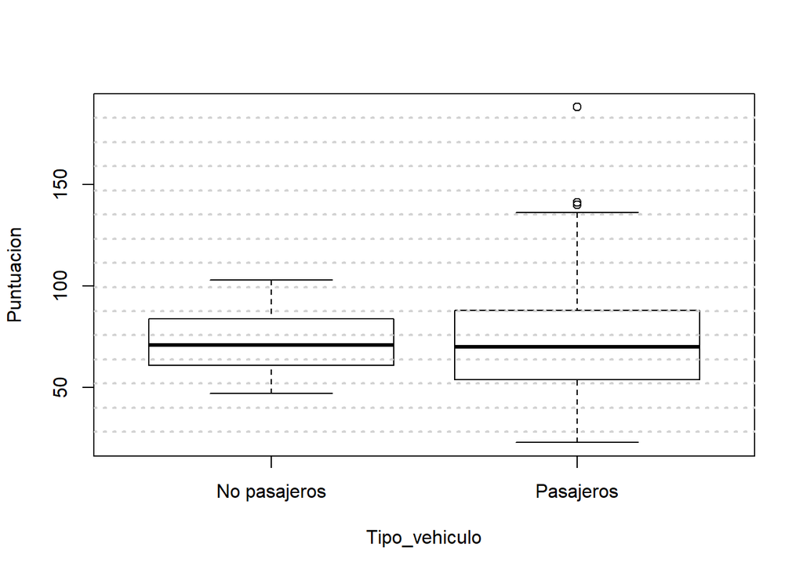

```r
boxplot(Puntuacion~Tipo_vehiculo,data=car)
grid(NA,15, lwd = 2);
```

# 3 **ANOVA-1**

**+ Se aplica ANOVA mediante la funcion de R aov() y guarda el resultado en la variable myAov**

```r
myAov = aov(Puntuacion~Tipo_vehiculo,data=car)
```

```r
summary(myAov)
```

```
##                Df Sum Sq Mean Sq F value Pr(>F)
## Tipo_vehiculo   1    195   195.3   0.293   0.59
## Residuals     115  76733   667.2
```

**¿la variable Puntuacion tiene medias diferentes según el tipo de vehículo?**

El resultado de F no es muy grande (0.293), lo que indica que las medias no son muy distintas entre si.

**Comprobación de los cálculos**

- A partir de los resultados de ANOVA, identifica la suma de cuadrados intra grupo (SSW) y la suma de cuadrados entre grupos (SSB).
- A partir de estos valores, calcula manualmente F y comprueba que coincide con el resultado del modelo ANOVA calculado.

**Varianza Intragrupos**

```r
varx1 <- sum ((car[car$Tipo_vehiculo=="Pasajeros",]$Puntuacion - mean(car[car$Tipo_vehiculo=="Pasajeros",]$Puntuacion)) ^2 )
varx1
```

```
## [1] 70368.08
```

```r
varx2 <- sum ((car[car$Tipo_vehiculo=="No pasajeros",]$Puntuacion - mean(car[car$Tipo_vehiculo=="No pasajeros",]$Puntuacion)) ^2 )
varx2
```

```
## [1] 6364.552
```

```r
SSW = varx1 + varx2
SSW
```

```
## [1] 76732.63
```

**Varianza Total**

```r
xall <- c(car[car$Tipo_vehiculo=="Pasajeros",]$Puntuacion,car[car$Tipo_vehiculo=="No pasajeros",]$Puntuacion)
xall
```

```
##   [1]  58  91  91  63  85 135  82  84  71  96  86  84 114 114  83  46  67  70
##  [19]  72  81 141  48  23  66  70  80  54 101  52  66  68 188  44  77  67  63
##  [37]  80  43  54  37  55  59  92  87  95 124 114  94  46  62  59  85  68  51
##  [55]  51  62  81  78  98 125 140  50  63  89  61 103  52  53  62  70  81  78
##  [73]  83  93 134 136  40  41  50  48  54  85  56  47  48  62  49  48  90  71
##  [91]  70  50  61  88  62 100  47  89  60  84  85  49  77  80  84  71  86  70
## [109]  71  72  81  76  61  55  52  62 103
```

```r
SST <- sum( (xall - mean(xall)) ^ 2 )
SST
```

```
## [1] 76927.97
```

**Varianza Entre Grupos**

```r
SSB <- SST - SSW
SSB
```

```
## [1] 195.3345
```

**m sería la cantidad de grupos, en este caso es igual a 2**

```r
m <-2
m
```

```
## [1] 2
```

**N sería la cantidad de observaciones, en este caso es 117**

```r
N <-length( xall )
N
```

```
## [1] 117
```

**Calculamos F**

```r
F <- (SSB / (m-1)) / (SSW/ (N-m))
F
```

```
## [1] 0.2927499
```

Interpreta los resultados obtenidos. ¿Coinciden con lo que pensabas tras ver los resultados del apartado anterior?

El resultado manualmente se puede decir que es mas exacto por disponer de mas decimales, pero el resultado es el mismo que utilizando la funcion aov.

- En cuanto a **F** es igual, en la funcion aov nos da 0.293 mientras que calculandolo manualmente nos da mayor cantidad de decimales, pero al redondearlo es el mismo resultado.
- Mean Sq nos da el mismo resultado igualemten en la funcion un 195.3 mientras que manualmente **SSB (Varianza Entre Grupos)** 195.33 con mayor cantidad de decimales
- El Resuadials de Sum Sq nos da como resultado 76733 y realizando el calculo manualmente el **SSW (Varianza Intragrupo)** nos da 76732.63 con una mayor cantidad de decimales

Calculamos Valor Crítico al 5%

```r
vc <- qf(0.05, m-1, N-m, lower.tail=F)
vc
```

```
## [1] 3.923599
```

# 4 **ANOVA-2**

Se crean dos grupos del mismo tamaño según si el precio del vehículo supera o no la mediana y se guarda en la variable GR_PRECIO

```r
Mediana = median(car$Precio)

car$GR_PRECIO <- NA
car[car$Precio <= Mediana,]$GR_PRECIO <- 1
car[car$Precio > Mediana,]$GR_PRECIO <- 2
```

Calculamos anova de la puntuacion de los grupos creados en el paso anterior

```r
myAov.GR_PRECIO = aov(Puntuacion~GR_PRECIO,data=car)
summary(myAov.GR_PRECIO)
```

```
##              Df Sum Sq Mean Sq F value Pr(>F)
## GR_PRECIO     1  38594   38594   115.8 <2e-16 ***
## Residuals   115  38333     333
## ---
## Signif. codes:  0 '***' 0.001 '**' 0.01 '*' 0.05 '.' 0.1 ' ' 1
```

Teniendo en cuenta que los los grupos son heterogéneos entre ellos y similares internamente, el valor de F es más alto y por tanto, las variables estarán relacionadas.

En este caso vemos que F es mucho mayor, cuanto más alto sea F, más están relacionadas las variables, lo que significa que las medias de la variable dependiente difieren o varían mucho entre los grupos de la variable independiente.

La signification es muy pequeña, de <2e-16, lo que quiere decir que las diferencias de las medias entre grupos son significativas y que hay estrecha relacion entre las variables.

Por lo tanto podemos concluir que la variable Precio esta mas relacionada con la punctuation que la variable tipo de vehiculo.

# 5 **Componentes Principales**

#Preparacion de datos

#Se muestran datos como enteros en centimetros en la columna Ancho, se unifican a metros.

```r
index.Anchocms<-which(grepl( "cms" , car$Ancho ))
```

```r
car$Ancho = gsub("cms","", car$Ancho)
```

Se eliminan los espacios en blanco de las cadenas

```r
car$Ancho<-trimws(car$Ancho, which = "both")

car[index.Anchocms,]$Ancho<-as.double(car[index.Anchocms,]$Ancho)/100
```

Se comprueba el tipo de dato de la variable “Ancho”

```r
typeof(car$Ancho)
```

```
## [1] "character"
```

```r
car$Ancho= round(as.numeric(car$Ancho),2)
```

**Proceso de extracción de características usando componentes principales.¿Por qué no incluimos en el análisis la variable Valor_usado? ¿Y la variable Puntuacion?**

```r
car2 <- car %>%
  select('Ventas', 'Precio', 'Motor', 'Caballos', 'Ejes_distancia', 'Ancho', 'Longitud', 'PesoBruto', 'Deposito_litro' , 'Consumo_litro')
```

Las variables Valor_usado y Puntuacion estan estrechamente relacionadas ya que son variables transformadas o calculadas que se obtienen a partir de las variables independientes.

##Matriz de correlacion

```r
MatrizCor = cor(car2)
MatrizCor
```

```
##                     Ventas      Precio       Motor   Caballos Ejes_distancia
## Ventas          1.00000000 -0.25170348  0.03811139 -0.1525376     0.40638925
## Precio         -0.25170348  1.00000000  0.64917095  0.8534555     0.06636377
## Motor           0.03811139  0.64917095  1.00000000  0.8616183     0.40881597
## Caballos       -0.15253759  0.85345552  0.86161827  1.0000000     0.22519860
## Ejes_distancia  0.40638925  0.06636377  0.40881597  0.2251986     1.00000000
## Ancho           0.17552359  0.30553701  0.67228775  0.5108921     0.67601058
## Longitud        0.27145048  0.18295753  0.53697785  0.4011560     0.85343022
## PesoBruto       0.06718400  0.51139975  0.74283025  0.5986026     0.67523109
## Deposito_litro  0.13803788  0.40646206  0.61689201  0.4797737     0.65770809
## Consumo_litro  -0.06687769 -0.47953874 -0.72467766 -0.5956731    -0.46949946
##                     Ancho   Longitud  PesoBruto Deposito_litro Consumo_litro
## Ventas          0.1755236  0.2714505  0.0671840      0.1380379   -0.06687769
## Precio          0.3055370  0.1829575  0.5113998      0.4064621   -0.47953874
## Motor           0.6722877  0.5369778  0.7428302      0.6168920   -0.72467766
## Caballos        0.5108921  0.4011560  0.5986026      0.4797737   -0.59567311
## Ejes_distancia  0.6760106  0.8534302  0.6752311      0.6577081   -0.46949946
## Ancho           1.0000000  0.7472367  0.7357371      0.6712508   -0.59783091
## Longitud        0.7472367  1.0000000  0.6849003      0.5631331   -0.46584948
## PesoBruto       0.7357371  0.6849003  1.0000000      0.8480066   -0.81869920
## Deposito_litro  0.6712508  0.5631331  0.8480066      1.0000000   -0.80848662
## Consumo_litro  -0.5978309 -0.4658495 -0.8186992     -0.8084866    1.00000000
```

##Corplot

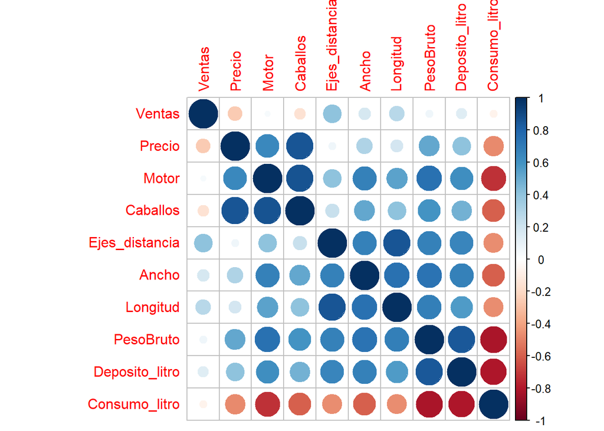

```r
corrplot(MatrizCor, method = "circle")
```

El PCA será util en este caso ya que este análisis de los componentes principales tiene sentido si existen altas correlaciones entre las variables, ya que es indicativo de que existe información redundante, por lo tanto, un número menor de variables serán capaces de explicar gran parte de la variabilidad total.

## 5.1 **PCA**

```r
pcaNonStandard <- prcomp(car2)
summary(pcaNonStandard)
```

```
## Importance of components:
##                              PC1       PC2       PC3      PC4   PC5   PC6   PC7
## Standard deviation     7.515e+04 1.370e+04 828.35717 3.36e+02 18.45 7.519 0.587
## Proportion of Variance 9.677e-01 3.217e-02   0.00012 2.00e-05  0.00 0.000 0.000
## Cumulative Proportion  9.677e-01 9.999e-01   0.99998 1.00e+00  1.00 1.000 1.000
##                           PC8     PC9    PC10
## Standard deviation     0.2279 0.07573 0.04879
## Proportion of Variance 0.0000 0.00000 0.00000
## Cumulative Proportion  1.0000 1.00000 1.00000
```

#PCA con datos estandarizados

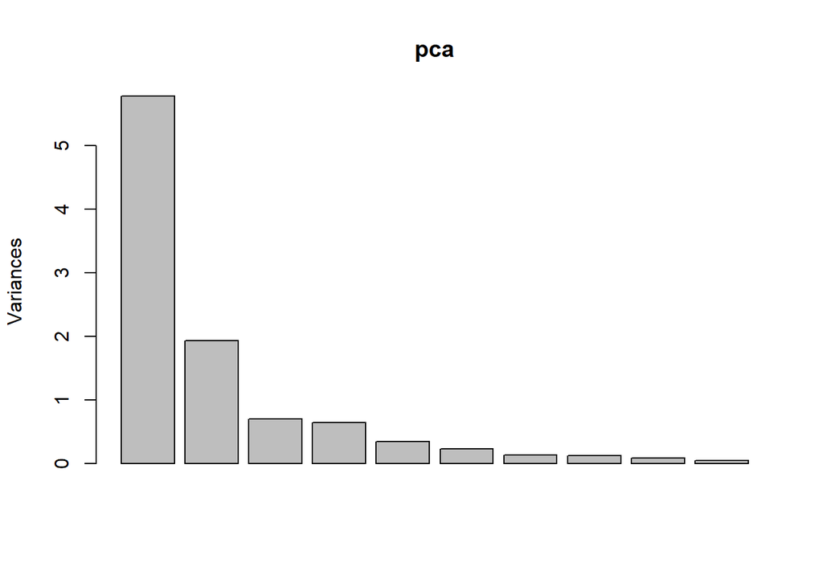

```r
pca <- prcomp(car2, scale=TRUE)

plot(pca)
```

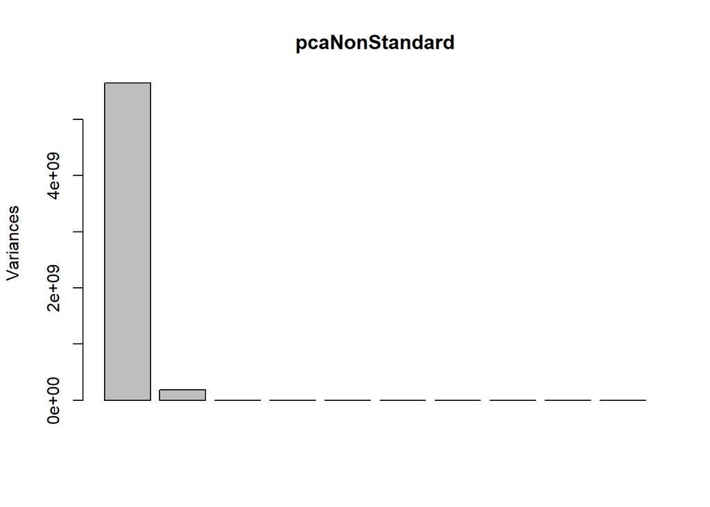

```r
plot(pcaNonStandard)
```

Se visualiza claramente la diferencia de la escala entre los modelos, posteriormente al estandarizar las variables para que tengan media 0 y desviación estándar 1, se intenta que las variables con mayor varianza no dominen al resto.

**Varianza acumulada** A partir de los valores de varianza de cada componente, se calcula la varianza acumulada El resultado debe coincidir con el que proporciona el modelo prcomp. **Muestra un gráfico con la varianza acumulada.**

```r
summary(pca)
```

```
## Importance of components:
##                           PC1    PC2     PC3     PC4     PC5     PC6     PC7
## Standard deviation     2.4035 1.3884 0.83555 0.79799 0.58519 0.47809 0.36830
## Proportion of Variance 0.5777 0.1928 0.06981 0.06368 0.03424 0.02286 0.01356
## Cumulative Proportion  0.5777 0.7704 0.84024 0.90392 0.93816 0.96102 0.97459
##                           PC8     PC9    PC10
## Standard deviation     0.3464 0.29444 0.21778
## Proportion of Variance 0.0120 0.00867 0.00474
## Cumulative Proportion  0.9866 0.99526 1.00000
```

```r
prop_varianza <- pca$sdev^2 / sum(pca$sdev^2)
prop_varianza
```

```
##  [1] 0.577661090 0.192764185 0.069814334 0.063679399 0.034244772 0.022857251
##  [7] 0.013564462 0.012002451 0.008669399 0.004742658
```

```r
prop_varianza_acum <- cumsum(prop_varianza)
prop_varianza_acum
```

```
##  [1] 0.5776611 0.7704253 0.8402396 0.9039190 0.9381638 0.9610210 0.9745855
##  [8] 0.9865879 0.9952573 1.0000000
```

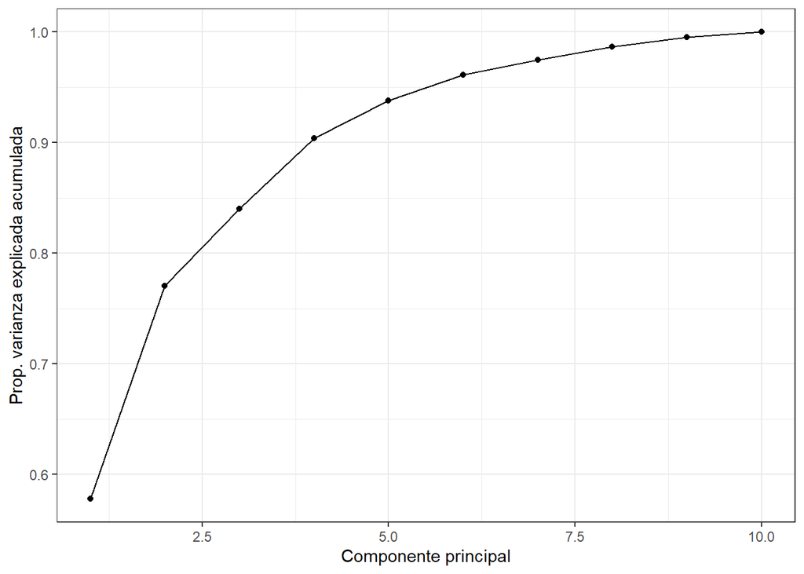

```r
ggplot(data = data.frame(prop_varianza_acum, pc = 1:10),
       aes(x = pc, y = prop_varianza_acum, group = 1)) +
  geom_point() +
  geom_line() +
  theme_bw() +
  labs(x = "Componente principal",
       y = "Prop. varianza explicada acumulada")
```

Interpretación Interpreta los resultados obtenidos. Calcula la varianza acumulada utilizando únicamente los 3 primeros componentes.

```r
prop_varianza_acum.3.componentes.total <- sum(prop_varianza[1:3])
prop_varianza_acum.3.componentes.total
```

```
## [1] 0.8402396
```

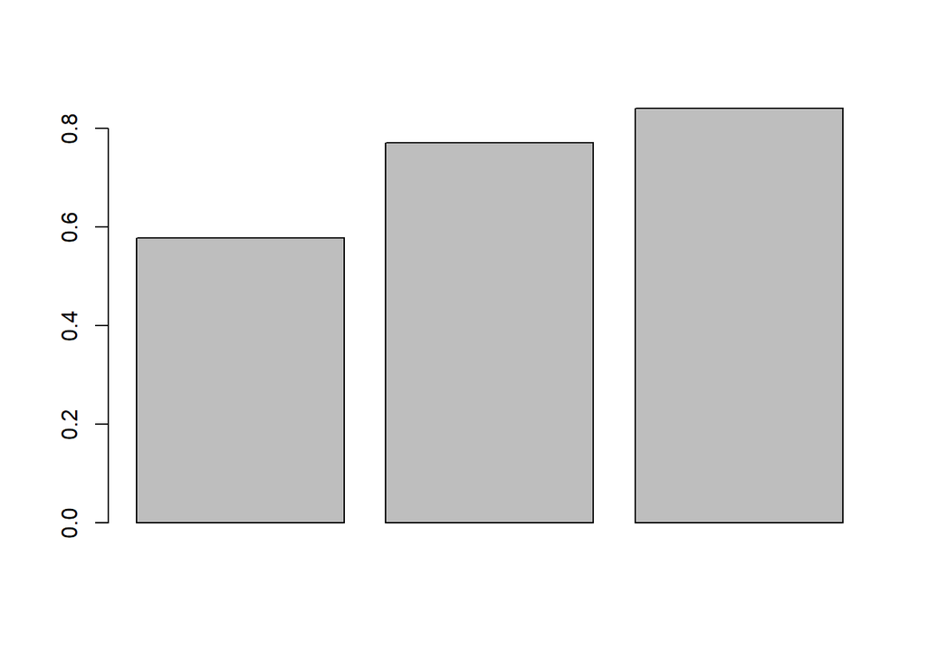

```r
prop_varianza_acum.3.componentes <- cumsum(prop_varianza[1:3])
barplot(prop_varianza_acum.3.componentes)
```

Visualizar la proyección sobre los dos primeros componentes A continuación, vamos a representar todos los datos del conjunto de datos proyectados sobre los dos primeros componentes que ha dado como resultado el PCA. Para ello, necesitamos transformar en primer lugar el conjunto de datos sobre un nuevo data frame que tendrá la proyección sobre los dos primeros componentes y el grupo al que pertenece cada instancia del conjunto de datos. Para ello, podemos aplicar la función predict pasando como parámetro el modelo PCA y los datos originales. Encontraréis ejemplos de cómo hacerlo en los ejemplos de la actividad preparatoria. Cuando ya tengáis los datos preparados, debéis visualizar el resultado en un scatter plot. Cada punto del conjunto tendrá unas coordenadas x,y en este gráfico, que son las dos primeras variables del conjunto de datos proyectados. Además, debéis pintar en un color diferente cada punto, en función de los valores de la variable Tipo_vehiculo.

```r
pca.predict<-predict(pca, newdata=car)[,1:2]
```

Se muestra el plot

[figure not shown]

```r
plot(pca.predict, col=car$Tipo_vehiculo)
legend("topleft", legend=levels(car$Tipo_vehiculo), pch=16, col=unique(car$Tipo_vehiculo))
```